# POLISCI 9590 - Lab9: OLS

William Poirier

2024-11-26

## 0. What we'll be doing

1. Review of OLS;
2. The `lm()` function;
3. Interpretation;
4. Exercise.

## 1. Review

- Linear model uses Ordinary Least Squares (OLS) to find the line of best fit.
- OLS is the Best Linear Unbiased Estimator (BLUE).
- Bivariate case:
  $$y=\beta_0+\beta_1
  x+\varepsilon$$
  $$\widehat
  y_i=\widehat\beta_0+\widehat\beta_1 x_i$$
- Minimize the sum of square residuals:
  $$SSR=\sum_{i=1}^n(y_i-\widehat
  y_i)^2$$

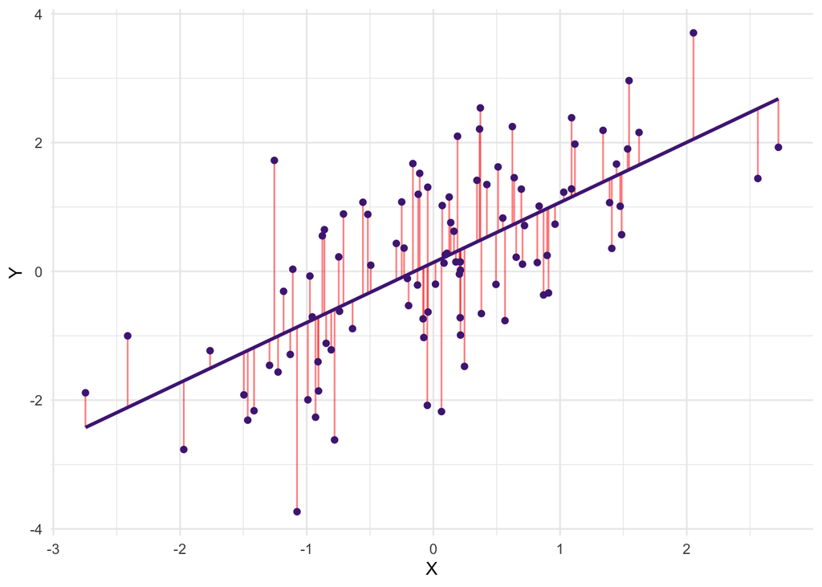

```r
# An Independent variable X
X <- rnorm(100,0,1)
# A Dependent variable Y
Y <- rnorm(100,0,1)+X
# Running the regression
mod <- lm(Y~X)
# Getting the predicted values (hats) from the model
Yhat <- predict(mod,type = "response")
# Making the graph
dat <- data.frame(X,Y,Yhat)
ggplot(dat,aes(x=X,y=Y))+
  geom_segment(aes(xend = X, yend = Yhat),color="red",alpha=0.5) +
  geom_point(color="#4F2683")+
  geom_smooth(method="lm",se = F,color="#4F2683")+
  theme_minimal()
```

## 2. The `lm()` function

Needs two things:

1. A `formula` type object;
2. The data.

```r
X1 <- rnorm(1000)
X2 <- rnorm(1000)
X3 <- rnorm(1000)
X4 <- sample(c("A","B","C"), 1000, replace =T)
Y <- rnorm(1000) + .5*X1 - .8* X2 + .2*X1*X2 - .3*X3^2 + ifelse(X4=="A",0.2,ifelse(X4=="B",0.4,0.6))
tmp <- data.frame(Y,X1,X2,X3,X4)
```

```r
# Formulas generally look like this
Y ~ X1 + X2

# You can add an interaction
Y ~ X1 + X2 + X1*X2

# A Squared term
Y ~ X1 + X2 + X1*X2 + I(X3^2)

# A categorical variable
Y ~ X1 + X2 + X1*X2 + I(X3^2) + factor(X4)
```

```r
mod1 <- lm(Y ~ X1 + X2,data=tmp)
summary(mod1)
```

```
##
## Call:
## lm(formula = Y ~ X1 + X2, data = tmp)
##
## Residuals:
##     Min      1Q  Median      3Q     Max
## -5.1452 -0.6923  0.0180  0.6911  3.3754
##
## Coefficients:
##             Estimate Std. Error t value Pr(>|t|)
## (Intercept)  0.08509    0.03451   2.466   0.0138 *
## X1           0.50269    0.03506  14.337   <2e-16 ***
## X2          -0.75844    0.03571 -21.236   <2e-16 ***
## ---
## Signif. codes:  0 '***' 0.001 '**' 0.01 '*' 0.05 '.' 0.1 ' ' 1
##
## Residual standard error: 1.091 on 997 degrees of freedom
## Multiple R-squared:  0.3911, Adjusted R-squared:  0.3898
## F-statistic: 320.1 on 2 and 997 DF,  p-value: < 2.2e-16
```

```r
mod2 <- lm(Y ~ X1 + X2 + X1*X2,data=tmp)
summary(mod2)
```

```
##
## Call:
## lm(formula = Y ~ X1 + X2 + X1 * X2, data = tmp)
##
## Residuals:
##     Min      1Q  Median      3Q     Max
## -5.1208 -0.6730  0.0398  0.7073  3.1520
##
## Coefficients:
##             Estimate Std. Error t value Pr(>|t|)
## (Intercept)  0.07961    0.03392   2.347   0.0191 *
## X1           0.50172    0.03445  14.564  < 2e-16 ***
## X2          -0.74760    0.03513 -21.278  < 2e-16 ***
## X1:X2        0.20987    0.03458   6.069 1.83e-09 ***
## ---
## Signif. codes:  0 '***' 0.001 '**' 0.01 '*' 0.05 '.' 0.1 ' ' 1
##
## Residual standard error: 1.072 on 996 degrees of freedom
## Multiple R-squared:  0.4128, Adjusted R-squared:  0.411
## F-statistic: 233.4 on 3 and 996 DF,  p-value: < 2.2e-16
```

```r
mod3 <- lm(Y ~ X1 + X2 + X1*X2 + I(X3^2),data=tmp)
summary(mod3)
```

```
##
## Call:
## lm(formula = Y ~ X1 + X2 + X1 * X2 + I(X3^2), data = tmp)
##
## Residuals:
##     Min      1Q  Median      3Q     Max
## -3.2078 -0.6813 -0.0052  0.6556  2.9619
##
## Coefficients:
##             Estimate Std. Error t value Pr(>|t|)
## (Intercept)  0.36635    0.03806   9.625  < 2e-16 ***
## X1           0.50401    0.03178  15.858  < 2e-16 ***
## X2          -0.76260    0.03243 -23.512  < 2e-16 ***
## I(X3^2)     -0.29846    0.02255 -13.234  < 2e-16 ***
## X1:X2        0.20914    0.03190   6.555  8.9e-11 ***
## ---
## Signif. codes:  0 '***' 0.001 '**' 0.01 '*' 0.05 '.' 0.1 ' ' 1
##
## Residual standard error: 0.9888 on 995 degrees of freedom
## Multiple R-squared:  0.5007, Adjusted R-squared:  0.4987
## F-statistic: 249.4 on 4 and 995 DF,  p-value: < 2.2e-16
```

```r
mod4 <- lm(Y ~ X1 + X2 + X1*X2 + I(X3^2) + factor(X4),data=tmp)
summary(mod4)
```

```
##
## Call:
## lm(formula = Y ~ X1 + X2 + X1 * X2 + I(X3^2) + factor(X4), data = tmp)
##
## Residuals:
##     Min      1Q  Median      3Q     Max
## -3.2156 -0.6708 -0.0086  0.6173  3.1599
##
## Coefficients:
##             Estimate Std. Error t value Pr(>|t|)
## (Intercept)  0.17870    0.05574   3.206  0.00139 **
## X1           0.49864    0.03126  15.951  < 2e-16 ***
## X2          -0.77483    0.03192 -24.277  < 2e-16 ***
## I(X3^2)     -0.30767    0.02223 -13.837  < 2e-16 ***
## factor(X4)B  0.12999    0.07631   1.703  0.08880 .
## factor(X4)C  0.45023    0.07469   6.028 2.34e-09 ***
## X1:X2        0.20251    0.03139   6.452 1.72e-10 ***
## ---
## Signif. codes:  0 '***' 0.001 '**' 0.01 '*' 0.05 '.' 0.1 ' ' 1
##
## Residual standard error: 0.9711 on 993 degrees of freedom
## Multiple R-squared:  0.5193, Adjusted R-squared:  0.5164
## F-statistic: 178.8 on 6 and 993 DF,  p-value: < 2.2e-16
```

## 3. Interpretation

- Using the `wage1` dataset from `wooldridge`, we regress `wage` on `educ`. Data from 1976.

```r
library(wooldridge)
data("wage1")

mod <- lm(wage~educ,wage1)
summary(mod)
```

```
##
## Call:
## lm(formula = wage ~ educ, data = wage1)
##
## Residuals:
##     Min      1Q  Median      3Q     Max
## -5.3396 -2.1501 -0.9674  1.1921 16.6085
##
## Coefficients:
##             Estimate Std. Error t value Pr(>|t|)
## (Intercept) -0.90485    0.68497  -1.321    0.187
## educ         0.54136    0.05325  10.167   <2e-16 ***
## ---
## Signif. codes:  0 '***' 0.001 '**' 0.01 '*' 0.05 '.' 0.1 ' ' 1
##
## Residual standard error: 3.378 on 524 degrees of freedom
## Multiple R-squared:  0.1648, Adjusted R-squared:  0.1632
## F-statistic: 103.4 on 1 and 524 DF,  p-value: < 2.2e-16
```

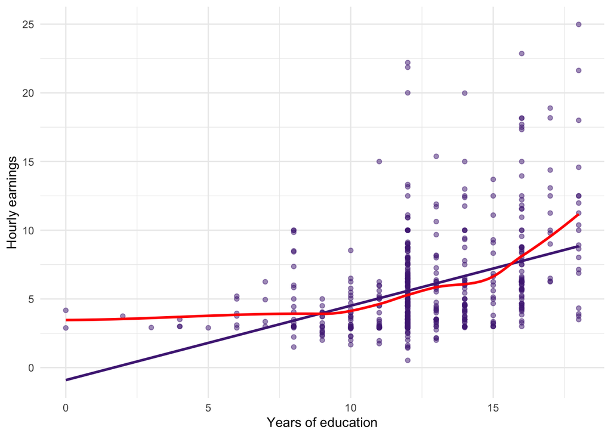

```r
ggplot(wage1,aes(educ,wage))+
  geom_point(color="#4F2683",alpha=0.5)+
  geom_smooth(method="lm",color="#4F2683",se=F)+
  geom_smooth(method="loess",color="red",se=F)+
  theme_minimal()+
  labs(x="Years of education",y="Hourly earnings")
```

- Using the `wage1` dataset from `wooldridge`, we regress `wage` on `tenure`. Data from 1976.

```r
mod <- lm(wage~tenure,wage1)
summary(mod)
```

```
##
## Call:
## lm(formula = wage ~ tenure, data = wage1)
##
## Residuals:
##     Min      1Q  Median      3Q     Max
## -8.8107 -2.0703 -0.9469  1.1899 16.6278
##
## Coefficients:
##             Estimate Std. Error t value Pr(>|t|)
## (Intercept)  4.99093    0.18516  26.955  < 2e-16 ***
## tenure       0.17733    0.02094   8.466 2.56e-16 ***
## ---
## Signif. codes:  0 '***' 0.001 '**' 0.01 '*' 0.05 '.' 0.1 ' ' 1
##
## Residual standard error: 3.467 on 524 degrees of freedom
## Multiple R-squared:  0.1203, Adjusted R-squared:  0.1187
## F-statistic: 71.68 on 1 and 524 DF,  p-value: 2.556e-16
```

- Using the `wage1` dataset from `wooldridge`, we regress `wage` on `exper`. Data from 1976.

```r
mod <- lm(wage~exper,wage1)
summary(mod)
```

```
##
## Call:
## lm(formula = wage ~ exper, data = wage1)
##
## Residuals:
##    Min     1Q Median     3Q    Max
## -4.936 -2.458 -1.112  1.077 18.716
##
## Coefficients:
##             Estimate Std. Error t value Pr(>|t|)
## (Intercept)  5.37331    0.25699  20.908  < 2e-16 ***
## exper        0.03072    0.01181   2.601  0.00955 **
## ---
## Signif. codes:  0 '***' 0.001 '**' 0.01 '*' 0.05 '.' 0.1 ' ' 1
##
## Residual standard error: 3.673 on 524 degrees of freedom
## Multiple R-squared:  0.01275,    Adjusted R-squared:  0.01086
## F-statistic: 6.766 on 1 and 524 DF,  p-value: 0.009555
```

- Using the `wage1` dataset from `wooldridge`, we regress `wage` on `educ`,`tenure`,`exper`, and `female`. Data from 1976.

```r
mod <- lm(wage~educ+tenure+exper+female,wage1)
summary(mod)
```

```
##
## Call:
## lm(formula = wage ~ educ + tenure + exper + female, data = wage1)
##
## Residuals:
##     Min      1Q  Median      3Q     Max
## -7.7675 -1.8080 -0.4229  1.0467 14.0075
##
## Coefficients:
##             Estimate Std. Error t value Pr(>|t|)
## (Intercept) -1.56794    0.72455  -2.164   0.0309 *
## educ         0.57150    0.04934  11.584  < 2e-16 ***
## tenure       0.14101    0.02116   6.663 6.83e-11 ***
## exper        0.02540    0.01157   2.195   0.0286 *
## female      -1.81085    0.26483  -6.838 2.26e-11 ***
## ---
## Signif. codes:  0 '***' 0.001 '**' 0.01 '*' 0.05 '.' 0.1 ' ' 1
##
## Residual standard error: 2.958 on 521 degrees of freedom
## Multiple R-squared:  0.3635, Adjusted R-squared:  0.3587
## F-statistic:  74.4 on 4 and 521 DF,  p-value: < 2.2e-16
```

## 4. Exercise

- Using the data from `approval`:
  1. Regress `approve` on `gasprice`. `gasprice` is in cents, `approve` is on a scale from 0 to 100% approval.
  2. What is the effect of a dollar increase in the price of gas on the predicted presidential approval rating?
  3. Make a plot of the relationship using `geom_smooth(method="lm")`.